# 5. Getting Spatial with sftrack

```r
library("sftrack")
# Make tracks from raw data
# raccoon <- read.csv(system.file('extdata/raccoon_data.csv', package='sftrack'))
data("raccoon", package = "sftrack")
raccoon$month <- as.POSIXlt(raccoon$timestamp)$mon + 1

raccoon$time <- as.POSIXct(raccoon$timestamp, tz = "EST")
coords <- c("longitude","latitude")
group <- list(id = raccoon$animal_id, month = as.POSIXlt(raccoon$timestamp)$mon+1)
time <- "time"
error <- "fix"
crs <- 4326
my_sftrack <- as_sftrack(data = raccoon, coords = coords, group = group, time = time, error = error, crs = crs)
my_sftraj <- as_sftraj(data = raccoon, coords = coords, group = group, time = time, error = error, crs = crs)
```

## Geometry column

As stated earlier, the geometry column is built using `sf`, so the column functions exactly as it would in `sf`. You can modify it and redefine it using the `sf` tools. More specifically the geometry column of an sf_track object is an `sfc` column. The main difference between a standard `sf` object created using `st_as_sf` is that we automatically allow empty geometries, where as this option is turned off by default in `st_as_sf()`.

```r
my_sftrack$geometry
```

```
## Geometry set for 445 features  (with 168 geometries empty)
## Geometry type: POINT
## Dimension:     XY
## Bounding box:  xmin: -80.28149 ymin: 26.06761 xmax: -80.27046 ymax: 26.07706
## Geodetic CRS:  WGS 84
## First 5 geometries:
```

```
## POINT EMPTY
```

```
## POINT (-80.27906 26.06945)
```

```
## POINT EMPTY
## POINT EMPTY
```

```
## POINT (-80.27431 26.06769)
```

An `sftrack` object is simply an `sfc` of `sfc_POINTS`, this contrasts with an `sftraj` object which is a mixture of a `POINT` and `LINESTRING`. This is because a trajectory can have a start point and an NA end point, a line segment, or an NA and an end point. This allows no-loss conversion back and forth between `sftrack` and an `sftraj`, and because linestrings can not have a NULL point in them.

```r
my_sftraj$geometry
```

```
## Geometry set for 445 features  (with 168 geometries empty)
## Geometry type: GEOMETRY
## Dimension:     XY
## Bounding box:  xmin: -80.28149 ymin: 26.06761 xmax: -80.27046 ymax: 26.07706
## Geodetic CRS:  WGS 84
## First 5 geometries:
```

```
## POINT EMPTY
```

```
## POINT (-80.27906 26.06945)
```

```
## POINT EMPTY
## POINT EMPTY
```

```
## LINESTRING (-80.27431 26.06769, -80.2793 26.06867)
```

This does mean that not all `sf` functions will handle an `sftraj` object like it would an `sftrack` if there are NAs in the data set. In these cases `st_is_empty()` can help to subset the points that contain geometry data.

## Working with sf

As an sftrack object is an sf object essentially all of the sf functions will work on it.

```r
library("sf")
st_length(my_sftraj)[1:10]
```

```
## Units: [m]
##  [1]   0.000000   0.000000   0.000000   0.000000 510.096380 107.395332
##  [7]   5.625847   0.000000   0.000000  15.748173
```

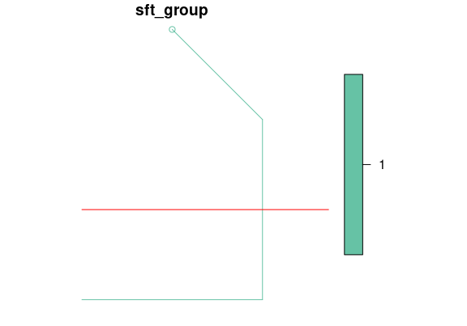

```r
df1 <- data.frame(
  id = c(1, 1, 1, 1),
  time = as.POSIXct("2020-01-01 12:00:00", tz = "UTC") + 60*60*(1:4),
  x = c(1, 3, 3, 2),
  y = c(1, 1, 3, 4)
)

road <- st_linestring(rbind(
  c(1, 2),
  c(5, 2),
  c(5, 0)
)
)

animal1 <- as_sftraj(df1)
plot(animal1)

plot(road,  col = "red", add = TRUE)
```

```r
# Does the animal cross the road?

any(st_intersects(animal1, road, sparse = FALSE))
```

```
## [1] TRUE
```

```r
# When?
animal1$time[st_intersects(animal1, road, sparse = FALSE)]
```

```
## [1] "2020-01-01 14:00:00 UTC"
```

```r
# How often does the animal stay near the road?
st_is_within_distance(animal1, road, 1)
```

```
## Sparse geometry binary predicate list of length 4, where the predicate
## was `is_within_distance'
##  1: 1
##  2: 1
##  3: 1
##  4: (empty)
```

```r
# How close is the animal from the road?

st_distance(animal1, road)
```

```
##      [,1]
## [1,]    1
## [2,]    0
## [3,]    1
## [4,]    2
```

The only thing to remember, is that a sftraj is a `GEOMETRY` column, and occasionally a function may not work with it. In those cases `is_linestring()` can be used to filter out points that do not have a t2.

## Plotting

### Base plotting

`sftrack` is built to work with `sf` base plot methods. This means you can use most of the `sf` plot methods, `sftrack` largely just controls the grouping of the plot then feeds it back to `plot.sf()`.

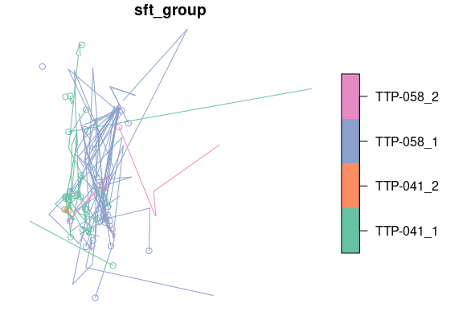

```r
plot(my_sftraj)
```

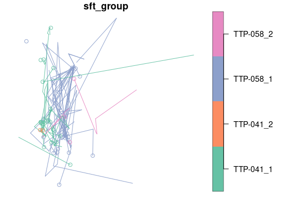

```r
plot(my_sftraj, key.pos = 4, key.width = lcm(4), key.length = 1)
```

```r
get_key_pos(my_sftraj)
```

[output not shown]

This means that everytime you change the active_group, the plot view will change.

```r
active_group(my_sftraj$sft_group) <- "id"
active_group(my_sftraj$sft_group)
```

```
## [1] "id"
```

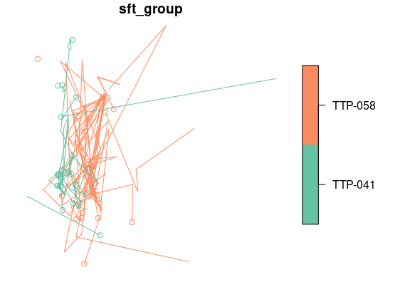

```r
plot(my_sftraj)
```

Most arguments for `plot.sf` are available to use as additional arguments to `plot`.

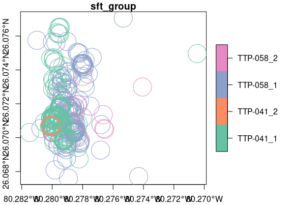

```r
plot(my_sftrack, axes = TRUE, cex = 5)
```

### ggplot2

This is a work in progress, but theres a geom_sftrack function that feeds `geom_sf` with the correct plotting information. Like `geom_sf` you input `data` into the geom_sftrack function and not into `ggplot()`. Again ggplot assumes active_group is the grouping variable. Plots vary slightly based on if they’re sftrack of sftraj class.

Geom_sftrack is essentially geom_sf(data = data, aes(color = group_labels(data))) with NULL points subetted out. This may help when a user requires more advanced modification than the geom_sftrack allows.

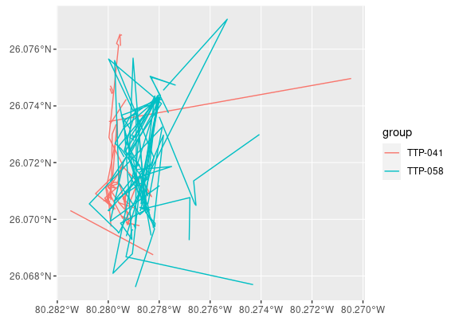

```r
library("ggplot2")
ggplot() + geom_sftrack(data = my_sftraj)
```

You can use geom_sftrack just like any other ggplot layer, which means you can continue to make manuscript quality plots.

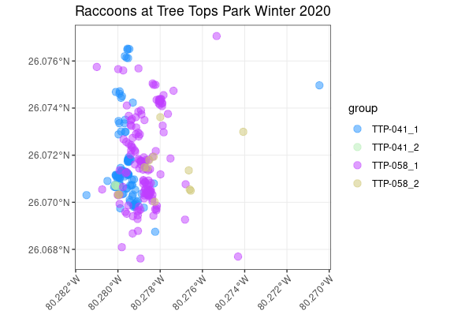

```r
cols <- c("TTP-041_1" = "dodgerblue1", "TTP-041_2" = "darkseagreen2",
          "TTP-058_1" = "darkorchid1", "TTP-058_2" = "khaki3")

ggplot() + geom_sftrack(data = my_sftrack, size = 3, alpha = 0.5) +
scale_color_manual(values = cols) +
  ggtitle("Raccoons at Tree Tops Park Winter 2020") +
  theme_bw() +
  theme(axis.text.x = element_text(angle = 45, hjust = 1))
```

## Special functions for working with an sftraj

To help with working with more complex sftraj objects, there is a growing suite of `sftraj` specific functions:

### Step mode in plotting

`sftraj` objects create linestrings for each row of data, as each row is not assumed to be related to the next row of data. This data structure may become inefficient to work with when plotting large data sets. When appropriate these trajectories can be generalized by combining linestrings where lines meet.

For plotting purposes we can create these linestrings quickly and plot them at much faster speeds than individual lines.

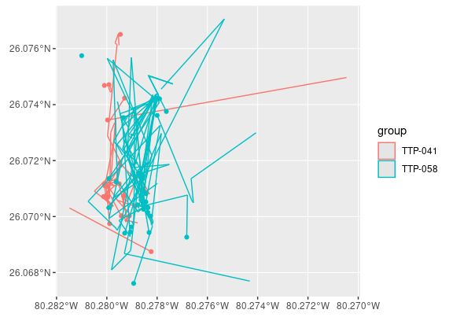

```r
library("ggplot2")
ggplot() + geom_sftrack(data = my_sftraj, step_mode = TRUE)
```

You’ll notice that the appearance of the plot changes as the POINTs are also displayed. This is because step mode adds POINTS to the plot that contain a fill as well as a color property.

### coord_traj

This function returns a data.frame (x,y,z) of the point at t1 of each sftraj geometry. It works nearly identically to `sf::st_coordinates()`.

```r
coord_traj(my_sftraj$geometry)[1:10, ]
```

```
##            [,1]     [,2]
##  [1,]        NA       NA
##  [2,] -80.27906 26.06945
##  [3,]        NA       NA
##  [4,]        NA       NA
##  [5,] -80.27431 26.06769
##  [6,] -80.27930 26.06867
##  [7,] -80.27908 26.06962
##  [8,] -80.27902 26.06963
##  [9,]        NA       NA
## [10,] -80.27900 26.06982
```

### pts_traj

If youd like to retain the geometries but still pull out t1 point you can use `pts_traj()`. This functions returns a list of the beginning point of each sftraj geometry, or an sfc column when using the argument `sfc = TRUE`.

```r
pts_traj(my_sftraj$geometry)[1:5]
```

```
## POINT EMPTY
```

```
## POINT (-80.27906 26.06945)
```

```
## POINT EMPTY
```

```
## POINT EMPTY
```

```
## POINT (-80.27431 26.06769)
```

```r
pts_traj(my_sftraj$geometry, sfc= TRUE)[1:5]
```

```
## Geometry set for 5 features  (with 3 geometries empty)
## Geometry type: POINT
## Dimension:     XY
## Bounding box:  xmin: -80.27906 ymin: 26.06769 xmax: -80.27431 ymax: 26.06945
## Geodetic CRS:  WGS 84
```

```
## POINT EMPTY
```

```
## POINT (-80.27906 26.06945)
```

```
## POINT EMPTY
## POINT EMPTY
```

```
## POINT (-80.27431 26.06769)
```

### is_linestring

May help if you’d like to quickly filter an `sftraj` object to just contain pure linestrings. `is_linestring()` returns TRUE or FALSE if the geometry is a linestring. This does not recalculate anything, it just filters out steps that contained NAs in either phase. Its nearly identical to st_is(x,‘LINESTRING’), but may be more intuitive for users.

```r
is_linestring(my_sftraj$geometry)[1:10]
```

```
##  [1] FALSE FALSE FALSE FALSE  TRUE  TRUE  TRUE FALSE FALSE  TRUE
```

```r
new_sftraj <- my_sftraj[is_linestring(my_sftraj$geometry), ]
head(new_sftraj)
```

[output not shown]

### Calculating step metrics of an sftraj

For use in movement models, you may need to calculate the dx, dy, length, and turn angles of each step. You can do that in `sftrack` using `step_metrics()`. It should be noted it will accept an `sftrack` object, however, it first converts the geometries internally to `sftraj` geometries and then calculates step metrics. As with other `sf` objects, the return is assumed to be in the units of the `crs` when not specified. Absolute angle is measured in radians.

```r
step_metrics(my_sftraj[1:10, ])
```

```
##            dx          dy       dist    dt abs_angle rel_angle       speed
## 1          NA          NA         NA  3600        NA        NA          NA
## 2    0.000000   0.0000000   0.000000  3600        NA        NA 0.000000000
## 3          NA          NA         NA  3600        NA        NA          NA
## 4          NA          NA         NA  3600        NA        NA          NA
## 5  498.309348 109.0329742 510.096380  3600 2.9272914        NA 0.141693439
## 6   22.473674 105.0175956 107.395332  3600 1.3588662 -1.568425 0.029832037
## 7    5.549011   0.9266259   5.625847  3574 0.1645841 -1.194282 0.001574104
## 8    0.000000   0.0000000   0.000000  3626        NA        NA 0.000000000
## 9          NA          NA         NA 32400        NA        NA          NA
## 10         NA          NA         NA    NA        NA        NA          NA
##                     sftrack_id
## 1  TTP-058_2019-01-19 00:02:30
## 2  TTP-058_2019-01-19 01:02:30
## 3  TTP-058_2019-01-19 02:02:30
## 4  TTP-058_2019-01-19 03:02:30
## 5  TTP-058_2019-01-19 04:02:30
## 6  TTP-058_2019-01-19 05:02:30
## 7  TTP-058_2019-01-19 06:02:30
## 8  TTP-058_2019-01-19 07:02:04
## 9  TTP-058_2019-01-19 08:02:30
## 10 TTP-058_2019-01-19 17:02:30
```